# Replication of People make the Same Bayesian Judgment They Criticize in Others by Cao, Kleiman-Weiner and Banaji (2019, Psychological Science)

Joseph Outa (joouta@stanford.edu)

November 25, 2020

## Introduction

Cao, Kleiman-Weiner and Banaji (2019) explores the moral and statistical imperatives that influence participants’ judgments about the likelihood of a hypothetical person being of a particular occupation. The authors note that, when asked who is more likely to be a doctor after a man and a woman perform surgery, the egalitarian moral imperative is to treat both as equally likely to be a doctor, whereas the statistical imperative is to consider priors - and in this case, priors favor the man being more likely to be the doctor. The replication target is study 5, which finds that participants judged a man to be more likely than a woman to be a pilot (a Bayesian judgment), and this judgment was held regardless of their moral evaluation of person X who made an egalitarian judgment.

I chose this paper because it’s an experimental application of Bayes theorem, a ubiquitous framework in the social sciences. Replicating it will require me to internalize the theorem’s basic intuitions such as how beliefs are updated with evidence as well as the computations associated with it such as how to calculate odds ratios and how to model posteriors from priors and likelihoods. The experimental paradigm involves a qualitative and computational exploration of how beliefs are updated with evidence, which is a great opportunity to think about how Bayesian principles fit in with people’s real world decision-making, an invaluable tool in a social scientist’s arsenal.

If the results of the original study hold, this study will have replicated 2 key findings: the first is that participants will judge a third party who makes a Bayesian judgment as being unfair, unjust, inaccurate and unintelligent. The second, and more important one, is that participants make Bayesian judgments about an airline scenario, with posteriors favoring the communicator being male rather than female, and these Bayesian judgments hold regardless of their evaluation of person X. The study is expected to be conducted on Amazon’s task crowd-sourcing marketplace, Mechanical Turk. Some possible expected challenges include low quality of data due to bots or inattentive participants, and the possibility of participants looking up answers to the filler questions about unrelated statistical phenomena.

Link to the [repository](https://github.com/psych251/cao2019)  
Link to the [Qualtrics survey](https://stanforduniversity.qualtrics.com/jfe/form/SV_80xBOBxnipQ3R4x)  
Link to the [preregistration](https://osf.io/h37qu)

## Methods

### Power Analysis

The original sample size for study 5 was 353 participants. For finding 1 (person X evaluations), the reported Cohen’s d effect size was 0.48. Using the G*Power software, the sample size required to achieve 80% power was calculated to be 37.

For finding 2 (the key finding - Bayesian judgments regardless of person X evaluations), the Cohen’s f effect size was calculated to be 0.48, and the sample size that would achieve 80% power was calculated to be 36.

### Planned Sample

The sample sizes 36 for finding 2 and 37 for finding 1 make it feasible to attempt replicate both findings simultaneously with a sample size of 37. To account for possible exclusions, a sample of 38 American Mturk workers will be ran.

### Materials and Procedure

Participants from Amazon Mturk will be recruited and compensated $0.85 each. The study will proceed in 3 parts, quoted from the original study:

> “In the first part, each participant was randomly assigned to learn that either a man or a woman had communicated with air traffic control during a flight. Participants provided their priors, posteriors, and likelihoods for this scenario”

> “In the second part, participants completed filler tasks consisting of unrelated statistical judgments (e.g., “What percentage of the earth’s surface is covered by land?”) and trivia (e.g., “The German word kummerspeck means excess weight gained from emotional overeating”).

> In the third part, participants completed the same procedure as in Study 1, in which they indicated which of three statements they agreed with and evaluated person X, who made the Bayesian judgment that a man who performed surgery is more likely to be a doctor than a woman who performed surgery.Participants then completed four Likert-type scales that assessed how (a) fair, (b) just, (c) accurate, and (d) intelligent person X’s statement was. Each scale ranged from 1 (e.g., extremely unfair) to 7 (e.g., extremely fair)."

The first part involving priors, posteriors and likelihoods will be composed of three sub-parts:

> "Part 1: priors. Participants will be instructed to imagine a man and a woman who work at the same airline. One person is a pilot and the other person is not a pilot, but who is the pilot and who is not is unknown. Participants will estimate the percentage chance that each person is the pilot. Because there are two hypotheses—either the man or the woman is the pilot (and the other is the not)—both estimates had to sum to 1. Thus, each participant will provide his or her subjective prior about each person’s profession (e.g., the man has a 75% chance of being the pilot; the woman has a 25% chance of being not the pilot).

> Part 2: posteriors. After providing priors, each participant will be randomly assigned to learn one of the following two pieces of data: (a) The man communicated with air traffic control(b) the woman communicated with air traffic control. After learning this datum, participants will again estimated the percentage chance that each person is the pilot. Thus, each participant will provide his or her subjective posterior.

> Part 3: likelihoods. Each participant will estimate two likelihoods: the likelihood of observing the datum given the hypothesis that the target they learned about is the pilot and the likelihood of observing the datum given the hypothesis that the target they learned about is not the pilot. For example, if a participant learned that the woman had communicated with air traffic control, that participant will estimate the percentage of female pilots who communicate with air traffic control and the percentage of female non-pilots who communicate with air traffic control. If a participant learned that the man had communicated with air traffic control, that participant will estimated the percentage of male pilots who communicate with air traffic control and the percentage of male non-pilots who communicate with air traffic control. Thus, each participant will provide his or her subjective likelihood estimates, which will be combined by forming a ratio. Each participant will be randomly assigned to estimate the corresponding likelihoods either before or after providing subjective priors and posteriors. Each participant’s priors and likelihoods will be entered into Bayes’s rule to compute a model posterior, which represents what the participant’s posterior should be from a statistical perspective. This model posterior will be compared with the posterior that the participant actually reported.

### Analysis Plan

Exclusions will be made based on three criteria:

- Participants who provide priors of either 0% of 100% since these cannot be updated in accordance with Bayes rule.
- Participants who indicate that they looked up answers to the trivia questions.
- In addition to the two criteria used in the original study, this study will also incorporate an attention check at the end of the survey that asks participants to indicate whether they were distracted, had trouble paying attention, or whether something else negatively affected their participation. Participants will be excluded who agree to any one of the above statements.

After exclusions, key descriptive statistics such as means and standard errors for judgments among participants in each condition will be computed, followed by exploratory and confirmatory analyses.

Two findings will be targets of replication:

- The main replication target (finding 2) which constitutes a two-way ANOVA with linear model fit examining the effects of person X evaluations ([1] negative to [7] positive) and target gender (male or female) on posterior judgments. These findings were summarized in an ANOVA table and also represented visually in figure 4.
- A secondary replication target (finding 1) will be a one-sample t-test to investigate the composite average Likert scores evaluating how fair, accurate, intelligent and just the participants would find Person X’s Bayesian judgment.

# The analysis

### Differences from Original Study

- The main difference in implementation is the sample size. The original sample size for study 5 was 353, however this replication will sample 38 participants from Mturk.
- A second difference is the additional self-reported attention check at the end of the study. This will help filter out participants whose responses are negatively affected by distractions.
- This study will not involve calculation of model posteriors, because they are irrelevant to the replication targets.

### Methods Addendum (Post-Data Collection)

#### Actual Sample

Data was collected from 38 English-speaking Americans on Mturk. The sample demographics were as follows  
Age: M = 38.67 years, SD = 11.14; 24 men, 13 women.

The exclusions made based on rules spelled out in analysis plan were as follows:  
* Exclusion 1: participants who indicated they looked up answers to trivia questions = 1  
* EXclusion 2: participants who were unable to update priors = 1  
* Exclusion 3: participants who failed self-reported attention check = 0

In sum, **2** exclusions were made, leaving a final sample of 36.

#### Differences from pre-data collection methods plan

None

## Results

### Data Preparation

Data Cleaning and exclusions

```r
dat <- dat %>%
   rename(cond1.prior_manPilot.womanFlightAttendant = X1.prior_1,  #prior prob that man is pilot
          cond1.prior_womanPilot.manFlightAttendant = X1.prior_2, #prior prob that woman is pilot
          cond1.post_manPilot.womanFlightAttendant = X1.post_1, #posterior prob that man is pilot
          cond1.post_womanPilot.manFlightAttendant = X1.post_2, #posterior prob woman is pilot
          cond1.lk_percent.male.pilots.comm.ATC = X1.lk_1_1,
          cond1.lk_percent.male.flightAttendants.comm.ATC = X1.lk_2_1,

          cond2.prior_manPilot.womanFlightAttendant = X2.prior_1, #prior prob that man is pilot
          cond2.prior_womanPilot.manFlightAttendant = X2.prior_2, #prior prob that woman is pilot
          cond2.post_manPilot.womanFlightAttendant = X2.post_1, #posterior prob that man is pilot
          cond2.post_womanPilot.manFlightAttendant = X2.post_2, #posterior prob woman is pilot
          cond2.lk_percent.female.pilots.comm.ATC = X2.lk_1_1,
          cond2.lk_percent.female.flightAttendants.comm.ATC = X2.lk_2_1,

          X1.free = c1.free, #convert to more manageable naming convention
          X2.free = c2.free
          )

dat <- dat %>%
  slice(3:length(dat$ResponseId)) %>% #remove first 2 rows (unnecessary titles)
  filter(lookup==2) %>% #exclusion1: exclude participants who said they looked up trivia answers
  filter(attn==7) %>% #exclusion2: exclude if participants report attention affected performance
  filter(!is.na(cond1.prior_manPilot.womanFlightAttendant)|!is.na(cond2.prior_manPilot.womanFlightAttendant)) %>%#cut blanks
  # arrange(cond1.prior_manPilot.womanFlightAttendant) %>% #sort by condition
  mutate(condition = ifelse(is.na(cond1.prior_manPilot.womanFlightAttendant), "2", "1")) %>% #create condition column
  dplyr::select(!starts_with("Q")) %>%  #remove columns with Trivia responses
  mutate_at(vars(age), as.numeric) %>%
  mutate_at(vars(gender), as.numeric) %>%
  mutate_at(vars(contains('cond')), as.numeric) %>% #judgments to numeric
  mutate_at(vars(contains('c1')), as.numeric) %>% #attributions to numeric
  mutate_at(vars(contains('c2')), as.numeric)


#demographic summary stats
mean(dat$age)
```

```
## [1] 38.67568
```

```r
sd(dat$age)
```

```
## [1] 11.14314
```

```r
count(dat$gender)
```

```
##   x freq
## 1 1   24
## 2 2   13
```

```r
tally(dat)
```

```
## # A tibble: 1 x 1
##       n
##   <int>
## 1    37
```

### Data Wrangling

Create prior percent and posterior percent columns by first computing odds ratios then converting to percent

```r
dat <- dat %>%
  #Create combined prior and target columns
  mutate(Prior.Man.Pilot = if_else(!is.na(cond1.prior_manPilot.womanFlightAttendant),
                                   cond1.prior_manPilot.womanFlightAttendant,
                                   cond2.prior_manPilot.womanFlightAttendant)) %>%
  mutate(Prior.Woman.Pilot = if_else(!is.na(cond1.prior_womanPilot.manFlightAttendant),
                                     cond1.prior_womanPilot.manFlightAttendant,
                                     cond2.prior_womanPilot.manFlightAttendant)) %>%
  mutate(target = if_else(condition == 1, "man", "woman")) %>%
  mutate_at(vars(target), factor) %>% # target to factor
  mutate(Prior.Target.Pilot = ifelse(target == "man", Prior.Man.Pilot, Prior.Woman.Pilot)) %>%
  mutate(able.to.update = ifelse(Prior.Target.Pilot == 1 | Prior.Target.Pilot == 0, "no", "yes")) %>%

  #Create combined posterior columns
  mutate(Posterior.Man.Pilot = ifelse(!is.na(cond1.post_manPilot.womanFlightAttendant),
                                      cond1.post_manPilot.womanFlightAttendant,
                                      cond2.post_manPilot.womanFlightAttendant)) %>%
  mutate(Posterior.Woman.Pilot = ifelse(!is.na(cond1.post_womanPilot.manFlightAttendant),
                                        cond1.post_womanPilot.manFlightAttendant,
                                        cond2.post_womanPilot.manFlightAttendant)) %>%
  mutate(Posterior.Target.Pilot= ifelse(target == "man",
                                        Posterior.Man.Pilot,
                                        Posterior.Woman.Pilot)) %>%

  #Create odds ratios then convert to percent
  mutate(prior.odds.ratio = ifelse(target == "man",
                                   Prior.Man.Pilot/ Prior.Woman.Pilot,
                                   Prior.Woman.Pilot/ Prior.Man.Pilot)) %>%
  mutate(posterior.odds.ratio = ifelse(target == "man",
                                   Posterior.Man.Pilot/ Posterior.Woman.Pilot,
                                   Posterior.Woman.Pilot/ Posterior.Man.Pilot)) %>%
  mutate(prior_percent = prior.odds.ratio/ (1 + prior.odds.ratio)) %>%
  mutate(posterior_percent = ifelse(is.infinite(posterior.odds.ratio),
                                    1,
                                    posterior.odds.ratio/ (1 + posterior.odds.ratio))) #convert to %, infinities = 1

#check
dat$Prior.Man.Pilot + dat$Prior.Woman.Pilot  # #confirm priors sum to 100%
```

```
##  [1] 100 100 100 100 100 100 100 100 100 100 100 100 100 100 100 100 100 100 100
## [20] 100 100 100 100 100 100 100 100 100 100 100 100 100 100 100 100 100 100
```

```r
count(dat$able.to.update)   # no = can't update priors
```

```
##     x freq
## 1  no    1
## 2 yes   36
```

```r
dat$Posterior.Man.Pilot + dat$Posterior.Woman.Pilot  #confirm posteriors sum 100
```

```
##  [1] 100 100 100 100 100 100 100 100 100 100 100 100 100 100 100 100 100 100 100
## [20] 100 100 100 100 100 100 100 100 100 100 100 100 100 100 100 100 100 100
```

```r
#exclude columns w demographic info
dat <- dat %>%
  filter(able.to.update=="yes") %>% #exclusion 3: first filter out participants unable to update priors
  dplyr::select(ResponseId,
                starts_with("cond"),
                starts_with("c1"),
                starts_with("c2"),
                Prior.Man.Pilot,
                Prior.Woman.Pilot,
                target,
                Prior.Target.Pilot,
                able.to.update,
                Posterior.Man.Pilot,
                Posterior.Woman.Pilot,
                Posterior.Target.Pilot,
                prior.odds.ratio,
                prior.odds.ratio,
                prior_percent,
                posterior_percent)

dat %>%
  group_by(target) %>%
  summarize(mean_prior = mean(prior_percent), #looks like higher priors for man than woman
            mean_posterior = mean(posterior_percent)) #mean still higher for man than woman
```

```
## # A tibble: 2 x 3
##   target mean_prior mean_posterior
##   <fct>       <dbl>          <dbl>
## 1 man         0.683          0.771
## 2 woman       0.241          0.513
```

### Exploratory analyses

#### Barplot showing belief updating

Mean prior posteriors in each condition

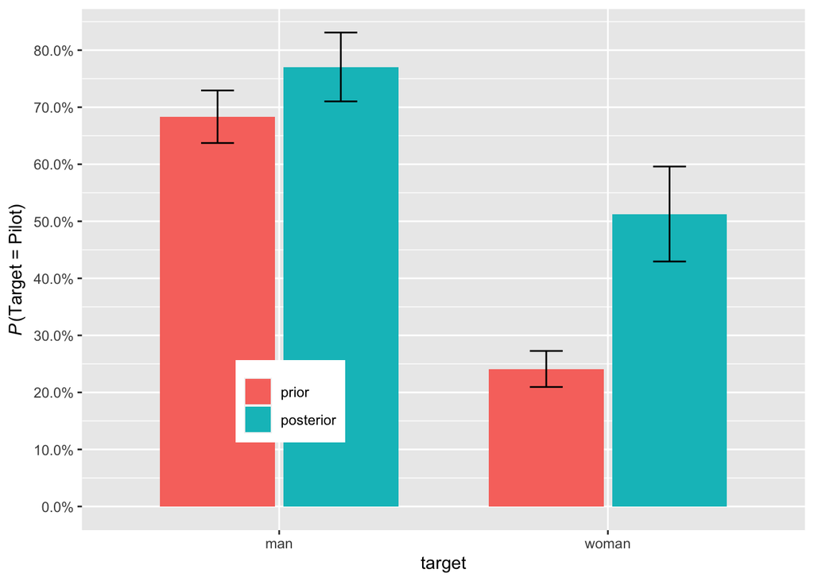

```r
stderror <- function(x) sd(x)/sqrt(length(x))
dodge <- position_dodge(width = 0.5)

bar <- dat %>%
  dplyr::select(prior_percent, posterior_percent, target) %>%
  pivot_longer(-c("target"),
               names_to = "type",
               values_to = "value") %>%
  mutate_at(vars(type), factor) %>%
  mutate(SE = stderror(value)) %>%
  mutate(type = fct_reorder(type, value))


bar %>%
  group_by(target, type) %>%
  summarize(mean = mean(value),
            SE = stderror(value)) %>%
  ggplot(aes(x = target, y = mean, fill = type)) +
  geom_bar(width = 0.7, position= position_dodge(width = 0.75), stat = "identity", ) +
  labs (y = expression(paste(italic(P), "(Target = Pilot)"))) +
  scale_y_continuous(breaks = seq(0, 1, 0.10),
                    label = percent_format()) +
   geom_errorbar(aes(ymax = mean + SE, ymin = mean - SE), position = position_dodge(0.75), width = 0.2) +
  scale_fill_discrete(labels = c("prior",
                                  "posterior")) +
  theme(legend.title = element_blank()) +
  theme(legend.position = c(0.25, 0.2)) +
  theme(legend.justification = c(0.25, 0.2)) +
  theme(legend.direction = "vertical")
```

#### Boxplot showing distribution of judgments across conditions

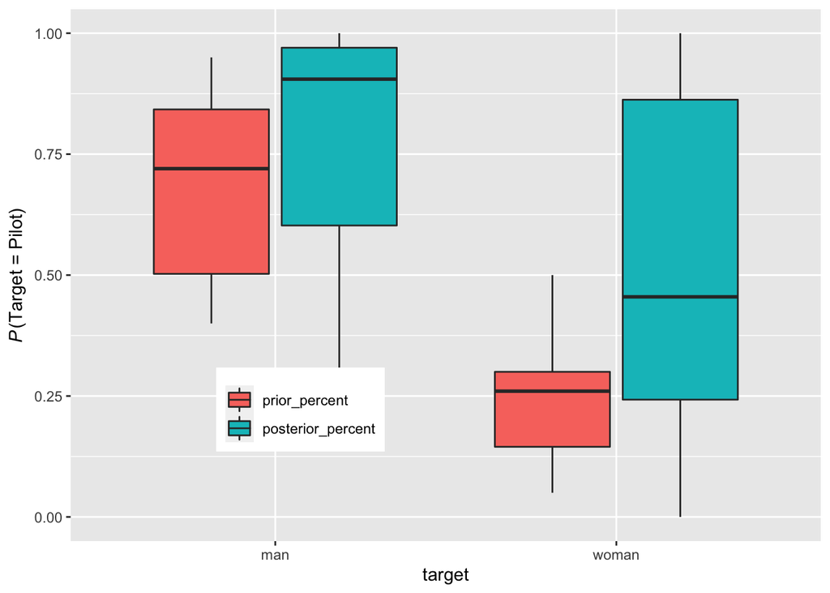

```r
bar %>%
  ggplot(aes(x = target, y = value,  fill = type)) +
  geom_boxplot() +
  labs (y = expression(paste(italic(P), "(Target = Pilot)"))) +
  theme(legend.title = element_blank()) +
  theme(legend.position = c(0.25, 0.2)) +
  theme(legend.justification = c(0.25, 0.2)) +
  theme(legend.direction = "vertical")
```

### Analyze evaluations of Person X - Finding 1

Composite mean evaluations in the replication attempt of finding 1 are:  
M = 2.99, SE = 0.26, t(35) = -3.89, p = 0.0004

The original composite mean and summary statistics are:  
M = 2.39, SE = 0.08, t(447) = -8.9, p<.001

This indicates that the finding that participants judged Person X negatively was *successfully* replicated, as indicated by Likert means below the midpoint of 4 on the Likert scale (unfair M = 3.17, SE = 0.30; unjust M = 2.86, SE = 0.29; inaccurate M = 2.77, SE = 0.31; unintelligent M = 3.13, SE = 0.29), and a significant (p = 0.0004) composite mean of 2.99

```r
# Combine responses into single columns for both conditions
dat <- dat %>%
  mutate(query = ifelse(condition == "1", c1.self, c2.self),
         intelligent = ifelse(condition == "1", c1.intel, c2.intel),
         accurate = ifelse(condition == "1", c1.acc, c2.acc),
         fair = ifelse(condition == "1", c1.fair, c2.acc),
         just = ifelse(condition == "1", c1.just, c2.just)) %>%
  mutate(composite.avg = (intelligent + accurate + fair + just) / 4) ## Compute composite average

dat %>%
  dplyr::select(intelligent, accurate, fair, just) %>%
  pivot_longer(cols = everything(), names_to = "variable", values_to = "value") %>%
  group_by(variable) %>%
  summarize(mean = mean(value),
            SE = stderror(value))
```

```
## # A tibble: 4 x 3
##   variable     mean    SE
##   <chr>       <dbl> <dbl>
## 1 accurate     2.78 0.309
## 2 fair         3.17 0.305
## 3 intelligent  3.14 0.290
## 4 just         2.86 0.290
```

```r
count(dat$query)
```

```
##   x freq
## 1 1   32
## 2 2    3
## 3 3    1
```

```r
32/35 # 91% agree that both the man and woman equally likely to be a doctor
```

```
## [1] 0.9142857
```

```r
3/35 # 8% agree that the man is more likely to be a doctor
```

```
## [1] 0.08571429
```

```r
1/35 # 3% agree that the woman is more likely to be a doctor
```

```
## [1] 0.02857143
```

```r
stderror(dat$composite.avg) # 0.26
```

```
## [1] 0.2601023
```

```r
t.test(dat$composite.avg, mu = 4) #Confirmatory analysis  (Finding 1)
```

```
##
##  One Sample t-test
##
## data:  dat$composite.avg
## t = -3.898, df = 35, p-value = 0.0004189
## alternative hypothesis: true mean is not equal to 4
## 95 percent confidence interval:
##  2.458075 3.514147
## sample estimates:
## mean of x
##  2.986111
```

```r
getwd()
```

```
## [1] "/Users/JosephOuta/Desktop/GitHub/cao2019/Writeup"
```